# idem: Inference in Randomized Controlled Trials with Death and Missingness

Chenguang Wang

2023-08-07

# Introduction

In randomized studies involving severely ill patients, functional outcomes are often unobserved due to missed clinic visits, premature withdrawal or death. It is well known that if these unobserved functional outcomes are not handled properly, biased treatment comparisons can be produced.

*R* package **idem** implement a procedure for comparing treatments that is based on the composite endpoint of both the functional outcome and survival. The procedure considers missing data imputation with a sensitivity analysis strategy to handle the unobserved functional outcomes not due to death.

# Data accepted by **idem**

In dataset accepted by **idem**, each row should represent a subject with treatment assignment, baseline coveraites, baseline outcome, post-randomization outcomes and survival time.

The **idem** package provides dataset *abc* from *ABC* trial as an example data set.

```r
head(abc);
```

```
##     AGE TRT SURV Y1 Y2
## 1 59.63   1  999 NA NA
## 2 66.89   0  999 49 52
## 3 59.70   1    1 NA NA
## 4 81.41   0   72 NA NA
## 5 66.52   1  999 51 45
## 6 40.27   0   65 NA NA
```

# Basic steps

There are four major steps in conducting imputation and inference using **idem**. First, a class *IDEMDATA* object should be generated by the function *imData*. Second, the imputation models will be fit to the data observed from the completers by the function *imFitModel*. Third, imputation can be conducted by the function *imImpAll*. Lastly, treatment effect estimation and hypothesis testing can be performed by function *imInfer*.

# Data generalization and visualization

In this step, the original dataset with specification parameters will be combined and checked. These parameters include variable names in the dataset, endpoint specification, duration of the study, etc.. If there is mis-specification, error messages will be generated. Otherwise, a class *IDEMDATA* object will be generated with certain data visulation functions implemented as its S3 methods.

```r
rst.data <- imData(abc, trt="TRT", outcome=c("Y1","Y2"), y0=NULL,
                   endfml="Y3", bounds=c(10,20), duration=365,
                   err.terminate = FALSE);
print(rst.data);
```

```
## Model specification is invalid. Please check the following:
##     No survival time specified
##     Endpoint formula error: Error in eval(substitute(expr), data, enclos = parent.frame()) :   object 'Y3' not found
##     Upper bound is smaller than some observed outcomes
```

```r
rst.data <- imData(abc, trt="TRT", surv="SURV", outcome=c("Y1","Y2"),
                   y0=NULL, endfml="Y2",
                   trt.label = c("UC+SBT", "SAT+SBT"),
                   cov=c("AGE"), duration=365, bounds=c(0,100));
```

The class *IDEMDATA* provides S3 plot and summary methods with multiple options for the visualization of the data.

## Spaghetti plot for survivors

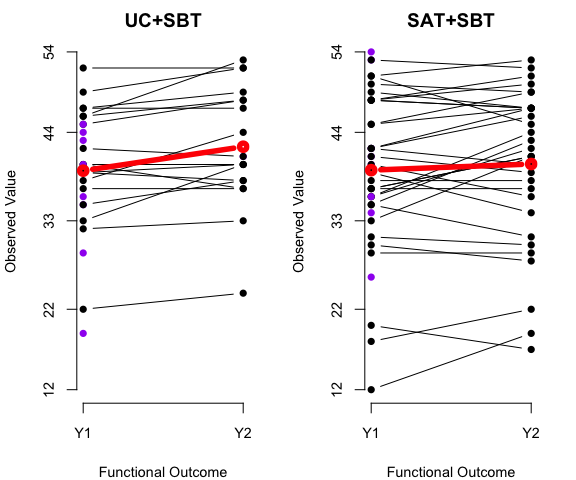

```r
plot(rst.data, opt = "survivor");
```

## Missing pattern frequency table

```r
summary(rst.data, opt = "misstable");
```

```
##                       Y1       Y2   UC.SBT  SAT.SBT
## Deaths on study                   58 (62%) 38 (41%)
## S=1             Observed Observed 18 (19%) 32 (34%)
## S=2             Observed  Missing   8 (9%)   8 (9%)
## S=3              Missing Observed   1 (1%)   0 (0%)
## S=4              Missing  Missing  9 (10%) 15 (16%)
## Total                                   94       93
```

## Missing pattern heatmap

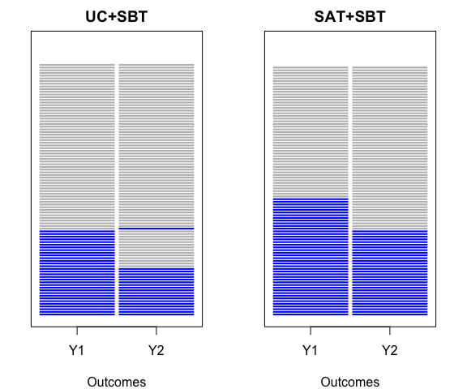

```r
plot(rst.data, opt = "missing", cols = c("blue", "gray"));
```

## Kaplan-Meier curves

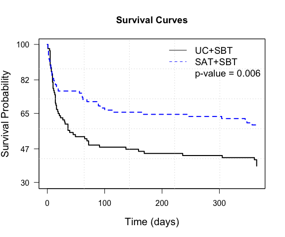

```r
plot(rst.data, opt = "KM");
```

# Missing data imputation

## Model fitting

To fit the imputation model to data observed from the completers, i.e. the subjects who were alive at the end of the study without missing data, the class *IDEMDATA* object needs to be passed to the function *imFitModel* as parameters. The result has class name **IDEMFIT**, which will be passed to imputation functions.

```r
rst.fit <- imFitModel(rst.data);
```

The goodness of fit diagnostics plots can be generated by the S3 plot method implemented for class *IDEMFIT*:

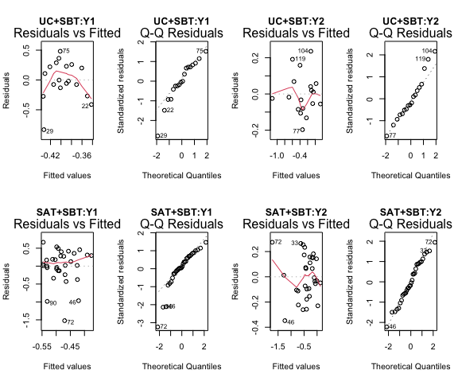

```r
plot(rst.fit, mfrow=c(2,4));
```

## Check convergence

The MCMC sampling is primarily done by **rstan**. It is suggested that the convergence of the MCMC chains should be checked. This can be done by the **imImpSingle** function which imputes missing data for an individual subject under the benchmark assumption.

```r
rst.mixing <- imImpSingle(abc[1,], rst.fit, chains = 4, iter = 2000, warmup = 1000);
```

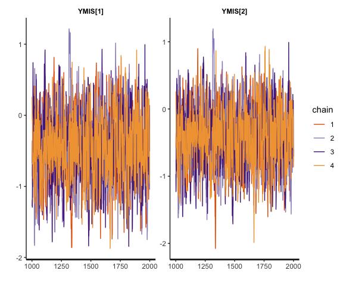

```r
plot(rst.mixing);
```

## Imputation

The following code shows how to use **imImpAll** to get the imputed complete datasets under benchmark assmption **delta=0** and for sensitivity analysis. We use **300** iterations to reduce the computation time.

```r
rst.imp <- imImpAll(rst.fit, deltas=c(-0.25,0,0.25),
                    normal=TRUE, chains = 4, iter = 300, warmup = 100);
rst.imp
```

[output not shown]

## Plot denisity of the imputed data

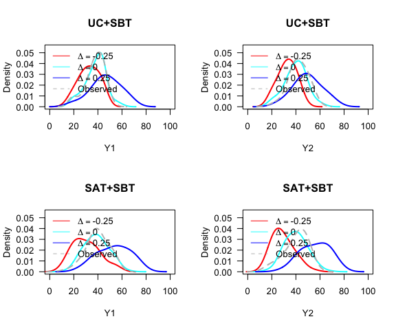

```r
plot(rst.imp, opt = "imputed", deltas = c(-0.25,0,0.25), xlim=c(0,100), endp=FALSE);
```

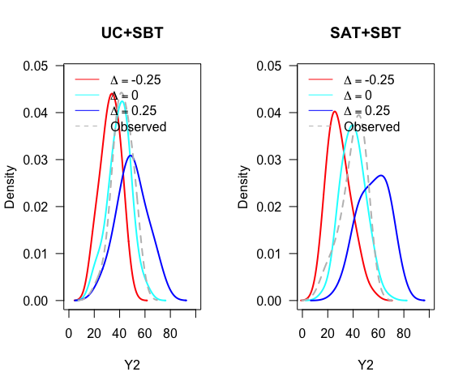

```r
plot(rst.imp, opt = "imputed", deltas = c(-0.25,0,0.25), xlim=c(0,100), endp=TRUE);
```

# Composite endpoint analysis

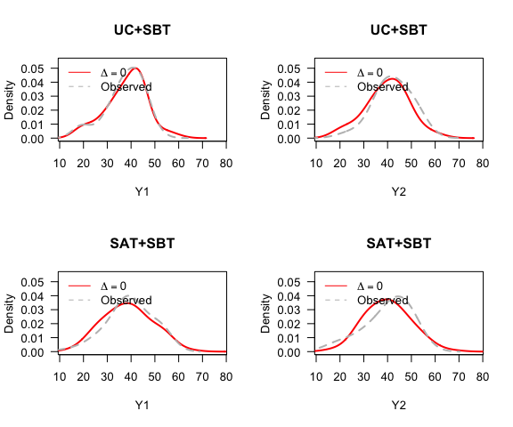

```r
plot(rst.imp, delta=0);
```

## Inference

The function *imInfer* implements bootstrap analysis for hypothesis testing, point estimation and confidence intervals of the treatment effects.

For illustration, we run **2** bootstrap samples by the following code:

```r
rst.test <- imInfer(rst.imp, n.boot = 2);
```

[output not shown]

[output not shown]

[output not shown]

[output not shown]

[output not shown]

[output not shown]

[output not shown]

[output not shown]

[output not shown]

[output not shown]

[output not shown]

[output not shown]

[output not shown]

[output not shown]

[output not shown]

[output not shown]

[output not shown]

[output not shown]

[output not shown]

[output not shown]

[output not shown]

[output not shown]

[output not shown]

[output not shown]

[output not shown]

[output not shown]

[output not shown]

[output not shown]

[output not shown]

[output not shown]

[output not shown]

[output not shown]

[output not shown]

[output not shown]

[output not shown]

[output not shown]

[output not shown]

[output not shown]

[output not shown]

[output not shown]

[output not shown]

[output not shown]

[output not shown]

[output not shown]

[output not shown]

[output not shown]

[output not shown]

[output not shown]

[output not shown]

[output not shown]

[output not shown]

[output not shown]

[output not shown]

[output not shown]

[output not shown]

[output not shown]

[output not shown]

[output not shown]

[output not shown]

[output not shown]

[output not shown]

[output not shown]

[output not shown]

[output not shown]

[output not shown]

[output not shown]

[output not shown]

[output not shown]

[output not shown]

[output not shown]

[output not shown]

[output not shown]

[output not shown]

[output not shown]

```r
rst.test
```

```
##
## The sensitivity parameters considered were
## [1] -0.25  0.00  0.25
##
## Treatment effect (theta) under different
## sensitivity parameters are:
##
##       Delta0 Delta1       Theta         SD       Q2.5        Q97.5       PValue
##  [1,]  -0.25  -0.25 -0.17414779 0.05925720 -0.2902898 -0.058005818 0.0032943650
##  [2,]   0.00  -0.25 -0.13301304 0.08740558 -0.3043248  0.038298750 0.1280614165
##  [3,]   0.25  -0.25 -0.08945321 0.10173861 -0.2888572  0.109950793 0.3792681721
##  [4,]  -0.25   0.00 -0.23408831 0.06359270 -0.3587277 -0.109448915 0.0002322695
##  [5,]   0.00   0.00 -0.18888126 0.09271171 -0.3705929 -0.007169645 0.0416203221
##  [6,]   0.25   0.00 -0.13411119 0.10681826 -0.3434711  0.075248752 0.2092943740
##  [7,]  -0.25   0.25 -0.29576756 0.07624329 -0.4452017 -0.146333454 0.0001047747
##  [8,]   0.00   0.25 -0.26099291 0.10245041 -0.4617920 -0.060193802 0.0108496340
##  [9,]   0.25   0.25 -0.20873942 0.12260724 -0.4490452  0.031566348 0.0886607630
##
## Treatment effect (quantiles) under different
## sensitivity parameters are:
##
##    Delta TRT    Q   QuantY QuantSurv      Q2.5     Q97.5 Q2.5_Surv Q97.5_Surv
## 3  -0.25   0 0.25       NA        14  15.00000  15.00000         1          1
## 8  -0.25   0 0.50       NA        72 305.00000 305.00000         1          1
## 13 -0.25   0 0.75 35.78072        NA  38.00000  38.00000         0          0
## 18 -0.25   1 0.25       NA        61  61.00000  61.00000         1          1
## 23 -0.25   1 0.50 22.00000        NA  25.34872  25.34872         0          0
## 28 -0.25   1 0.75 39.08344        NA  41.00000  41.00000         0          0
## 33  0.00   0 0.25       NA        14  15.00000  15.00000         1          1
## 38  0.00   0 0.50       NA        72 305.00000 305.00000         1          1
## 43  0.00   0 0.75 38.00000        NA  40.95547  40.95547         0          0
## 48  0.00   1 0.25       NA        61  61.00000  61.00000         1          1
## 53  0.00   1 0.50 29.90955        NA  30.00000  30.00000         0          0
## 58  0.00   1 0.75 42.68621        NA  44.00000  44.00000         0          0
## 63  0.25   0 0.25       NA        14  15.00000  15.00000         1          1
## 68  0.25   0 0.50       NA        72 305.00000 305.00000         1          1
## 73  0.25   0 0.75 40.00000        NA  44.38583  44.38583         0          0
## 78  0.25   1 0.25       NA        61  61.00000  61.00000         1          1
## 83  0.25   1 0.50 34.00000        NA  31.00000  31.00000         0          0
## 88  0.25   1 0.75 47.00000        NA  48.80214  48.80214         0          0
##
##
## The hypothesis testing and confidence intervals are
## based on 2 bootstrap samples. Please consider more
## bootstrap samples (e.g. >100) for the validity
## of the results.
```

A contour plot of p-values in the sensitivity analysis results can be generated by the S3 method of the result returned by **imInfer**:

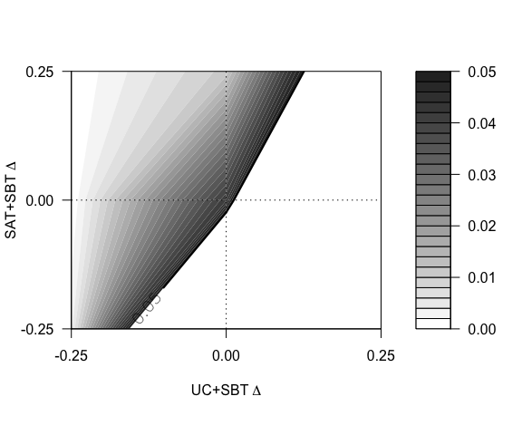

```r
plot(rst.test, nlevels = 30, con.v=0.05, zlim=c(0, 0.05));
```

# Graphical user interface (GUI)

The **idem** package provides a web-based GUI for composite endpoint analysis. The GUI can be accessed by

```r
imShiny();
```